# DES CosmoSIS mini-tutorial

Marc Paterno

12/5/2018 – version 0.1

# 1 CosmoSIS: O que é isso?

CosmoSIS is a *modular* MCMC parameter estimation system. It also supports related calculations, *e.g.* predictions of observations from different cosmological models.

The CosmoSIS team welcome contributions to CosmoSIS. And you’ll get credit whenever someone uses your contribution.

CosmoSIS is found on BitBucket: https://bitbucket.org/joezuntz/cosmosis/wiki/Home.

There are many moving parts; follow the installation instructions with care. If you’re installing on macOS, or on a non CentOS or Ubuntu Linux system, my personal recommendation is to use the *Docker installation*, at least at this time.

# 2 Parts of CosmoSIS

CosmoSIS is a Python program, with parts written in C, C++, and Fortran.

A CosmoSIS program consists of:

- one *sampler*
  - a sampler generates points a the multi-dimensional parameter space, describing a cosmology (and maybe a bunch of nuisance parameters).
  - CosmoSIS provides a variety of samplers; see the **Samplers** section of the wiki.
- one or more *modules*, in a sequence called the *pipeline*
  - *physics modules* calculate quantities derived from the cosmology (and nuisance parameters), and pass them on to later modules in the pipeline.
  - *likelihood modules* calculate a likelihood (for some data), based upon the cosmology.
  - A module can do both.

Modules can be written in Python, C, C++, or Fortran.

# 3 CosmoSIS comes with various software tools

A released version of CosmoSIS comes with specific versions of various software products. This is intended to make reproducibility easier.

The current release includes, *e.g.*:

| product | version |
| --- | --- |
| cfitsio | v3_37_0 |
| cython | v0_25_2a |
| fftw | v3_3_6_pl1a |
| gcc | v6_3_0 |
| gsl | v2_1 |
| lapack | v3_7_0 |
| minuit2 | v5_34_14b |
| mpich | v3_2_0b |
| numpy | v1_12_0 |
| pyfits | v3_4 |
| python | v2_7_13d |
| pyyaml | v3_12c |
| scipy | v0_19_0 |
| sqlite | v3_16_02_00a |

and through *pip*:

| package | version |
| --- | --- |
| astropy | 2.0.9 |
| emcee | 2.2.1 |
| ipython | 5.8.0 |
| ipython-genutils | 0.2.0 |
| matplotlib | 2.0.0 |
| mpi4py | 3.0.0 |
| pyfits | 3.4 |
| scipy | 0.19.0 |

# 4 Running CosmoSIS

The CosmoSIS main program is named *cosmosis*. A run is configured with two configuration files, usually called a “ini file” and a “values file”.

The *ini file* tells the program what sampler to use, and what modules to run in the pipeline. It also provides configuration information for the sampler and modules. Additionally, it specifies the *values file* to be used.

The *values file* specifies the names and ranges of the parameters of the space being sampled.

An optional *priors file* can be used to specify non-uniform priors.

# 5 Now for the live example, and questions!

The example with reproduce the calculations that Kathy showed at the Clusters plenary meeting. The plotting is left as an exercise for the student…

We’ll be using the *test* sampler, which is not really a MCMC sampler; it generates a single point. It is useful to verify that your pipeline is working, or to look at the physics parameter calculations for a single cosmology (which is what we are using it for).

The output of the sampler is a set of text files, in a directory structure:

```
.
├── cmb_cl
│   ├── bb.txt
│   ├── ee.txt
│   ├── ell.txt
│   ├── te.txt
│   └── tt.txt
├── cosmological_parameters
│   └── values.txt
├── distances
│   ├── a.txt
│   ├── d_a.txt
│   ├── d_l.txt
│   ├── d_m.txt
│   ├── h.txt
│   ├── mu.txt
│   ├── values.txt
│   └── z.txt
├── linear_cdm_transfer
│   ├── delta_cdm.txt
│   ├── k_h.txt
│   ├── values.txt
│   └── z.txt
├── mass_function
│   ├── dndlnmh.txt
│   ├── dndlnrh.txt
│   ├── m_h.txt
│   ├── r_h.txt
│   ├── values.txt
│   └── z.txt
└── matter_power_lin
    ├── k_h.txt
    ├── p_k.txt
    ├── values.txt
    └── z.txt
```

The directory names what *section* of the output is being printed; a section is a group of related parameters. What sections are produced depends on the modules that are run; see each module’s documentation for details. The files are text-format dumps of `numpy` vectors (possibly multi-dimensional).

CosmoSIS provides a Python script `postprocess`, which can make many plots out-of-the box, and which is configurable (through `matplotlib`) to generate others.

# 6 A note of caution

This is not a general tutorial on MCMC techniques.

However… it seems all to common for people to trust the output of a MCMC calculation without testing. There is a substantial literature on techniques for diagnosing the convergence (or, more properly, diagnosing *failure to converge*) of MCMC chains.

Automatic tools will calculate whatever you tell them to calculate. Nothing can replace a *thoughtful scientist*, who verfies that his or her calculations are working correctly. Please investigate!

For **R** users, I suggest starting with the `coda` package, which implements many of the tests popular in the literature, and which provides references for them.

# 7 Shameless plug and contribution request

The *very early* beginning of an R package to support use of **R** for analysis of CosmoSIS output is at https://github.com/marcpaterno/rcosmosis. Please feel free to contribute (fork and send pull requests).

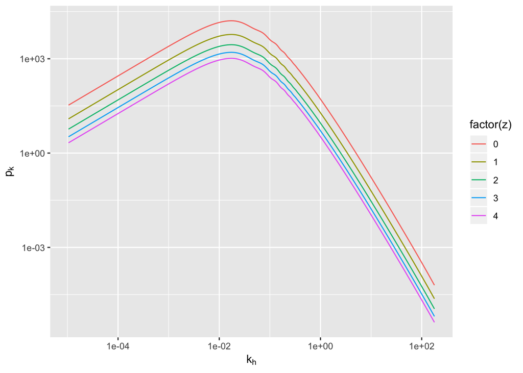

```r
x <- make.matterpower.dataframe("output/tutorial_a/matter_power_lin/", "a")
plot1 <- x %>%
         filter(z %in% c(0.0, 1., 2.0, 3., 4.)) %>%
         ggplot(aes(x = k_h, y = p_k, colour = factor(z)))
plot1 + scale_x_log10() + scale_y_log10() +
        geom_line() +
        xlab(TeX("$k_h$")) + ylab(TeX("$p_k$"))
```